# Analysis and Forecast of Retail Data Analytics

By: Chetan Alla

### Introduction

The retail industry has exploded in poulartiy with over the past decade with the introduction of the interent. Now, the next big thing is here: Artificial Inteligence. Many retail conglomorates want to make use of this new and fast emerging tecnhonlogy. However, a challenge of modeling retail data is that the models have to make predictions or decisions on a limited dataset. Things such as holidays and special events occur only a few times a year, making it difficult to make predictions with so little data.

In this notebook, I will walk you through the entire data science pipline, by analyzing a dataset containing a few years of weekly data on 45 store locations of a major US department chain. Although we have access to 3 files, we will mainly focus on features.csv and train.csv.

From this dataset, I

- Plot all the data over time
- Generate a heatmap showing correlations between all the data
- Gather useful metrics such as best/worst performing days and stores.
- Forcast Weekly_Sales, CPI, Unemployment, and Temperature using the [Neural Prophet](https://github.com/ourownstory/neural_prophet) model.

### Import libraries and data

Here, I import the necessary python libraries and the datasets. I have sourced the dataset from Kaggle which can be found here: https://www.kaggle.com/manjeetsingh/retaildataset

For this dataset we will be using:

- Pandas
- Matplotlib
- Seaborn
- Neural Prophet
- Pickle
- Sklearn

```python
import pandas as pd
import matplotlib.pyplot as plt
import seaborn as sns
!pip install neuralprophet
from neuralprophet import NeuralProphet
import pickle
from sklearn.model_selection import train_test_split
from datetime import timedelta

file1 = 'drive/MyDrive/data/features.csv'
file2 = 'drive/MyDrive/data/train.csv'
file3 = 'drive/MyDrive/data/test.csv'

features = pd.read_csv(file1)
train = pd.read_csv(file2)

pd.set_option("display.max_columns", None)
```

### Merging and Cleaning Data

Even data given specifically for data sceince inference is not ready to use out of the box. There are always missing values or values in an unusable format. This is why we need to preform a process called data cleaning. This is where we get the data into the proper format we require without any bad values. This is what I do in this section.

Here I merge the features and train table into one data frame. Then, I convert the Date column to the datetime datatype and drop all rows with missing values for CPI, Unemployment, and Weekly Sales. Instead of looking at individual stores and departments, I sum the sales of each store and department to get the weekly sales for the entire chain. For Markdowns and Temperature, I will just take the mean. Since Fuel Price, CPI, and Unemployment are all constant for a given week, we can also take the mean of them since it will result in the same value.

```python
features = pd.merge(features, train, on=["Store", "Date", "IsHoliday"], how="left")

features['Date'] = pd.to_datetime(features['Date'])
cleaned_features = features.dropna(subset=["CPI", "Unemployment", "Weekly_Sales"])
cleaned_features = cleaned_features.fillna(0)

total_weekly_sales = cleaned_features.groupby(by=["Date"], as_index=False)["Weekly_Sales"].sum()
cleaned_features = cleaned_features.groupby(by=["Date"], as_index=False)[["Temperature", "Fuel_Price", "MarkDown1", "MarkDown2", "MarkDown3", "MarkDown4", "MarkDown5", "CPI", "Unemployment", "IsHoliday"]].mean()
cleaned_features = pd.merge(cleaned_features, total_weekly_sales, on=["Date"], how="left")
cleaned_features.head()
```

|  | Date | Temperature | Fuel_Price | MarkDown1 | MarkDown2 | MarkDown3 | MarkDown4 | MarkDown5 | CPI | Unemployment | IsHoliday | Weekly_Sales |
| --- | --- | --- | --- | --- | --- | --- | --- | --- | --- | --- | --- | --- |
| 0 | 2010-02-05 | 33.277942 | 2.717869 | 0.0 | 0.0 | 0.0 | 0.0 | 0.0 | 167.398405 | 8.576731 | False | 49750740.50 |
| 1 | 2010-02-12 | 33.361810 | 2.696102 | 0.0 | 0.0 | 0.0 | 0.0 | 0.0 | 167.384138 | 8.567309 | True | 48336677.63 |
| 2 | 2010-02-19 | 37.038310 | 2.673666 | 0.0 | 0.0 | 0.0 | 0.0 | 0.0 | 167.338966 | 8.576351 | False | 48276993.78 |
| 3 | 2010-02-26 | 38.629563 | 2.685642 | 0.0 | 0.0 | 0.0 | 0.0 | 0.0 | 167.691019 | 8.561375 | False | 43968571.13 |
| 4 | 2010-03-05 | 42.373998 | 2.731816 | 0.0 | 0.0 | 0.0 | 0.0 | 0.0 | 167.727351 | 8.572689 | False | 46871470.30 |

### Plotting all the data in the cleaned dataset

Using MatPlotLib, I plotted all the features over time. The general documentation for MatPlotLibcan be explored here: https://matplotlib.org/3.3.3/api/_as_gen/matplotlib.pyplot.plot.html.

From this, there are already clear trends within the dataset:

- Temperature swings from low to high as the seasons change throughout the year. It is clear that this data is in degrees Fahrenheit since the temperature goes near 80°.
- CPI, Fuel Price, and Unemployment are fairly accruate. Fuel Price and CPI have had an upward trend while Unemployment has has a downward trend.
- There doesn't seem to be any markdown data until the end of 2011. There is a big spike in both markdowns and weekly sales during the winter holidays. This chain also had a little spike in markdowns in August around the back to school season.
- Weekly Sales have a big spike during the winter holidays, but remain somewhat flat for the rest of the year.

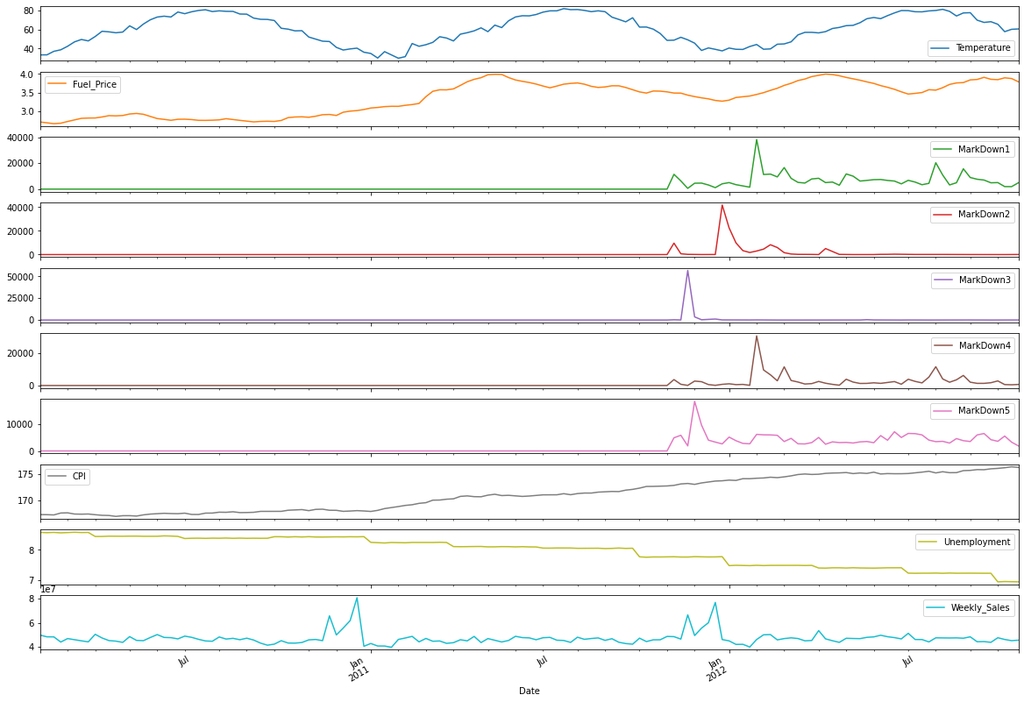

```python
cleaned_features[["Date", "Temperature", "Fuel_Price", "MarkDown1", "MarkDown2", "MarkDown3", "MarkDown4", "MarkDown5", "CPI", "Unemployment", "IsHoliday", "Weekly_Sales"]].plot(x="Date", subplots=True, figsize=(20, 15))
plt.show()
```

### Generating a heatmap showing correlations between all the columns

In this section we have used seaborn to create a heatmap, which shows the correlations between all of the features. The general documentaton for Seaborn can be found here: https://seaborn.pydata.org/

The interesting thing is that chain-wide weekly sales doesn't seem to have a correlation to any of the other columns in the dataset. Even if it did, using it to predict weekly sales would be a challenging problem since this is a time series datset and we can't just give our model future data.

I also see some corelations that make sense according to basic economics, such as CPI, Unemployment, and Fuel Price.

It is suprising however, to see that markdown 5 and unemployment have a strong negative correlation. But correlation is not causation, so it is likely that some other factor is affecting these two values.

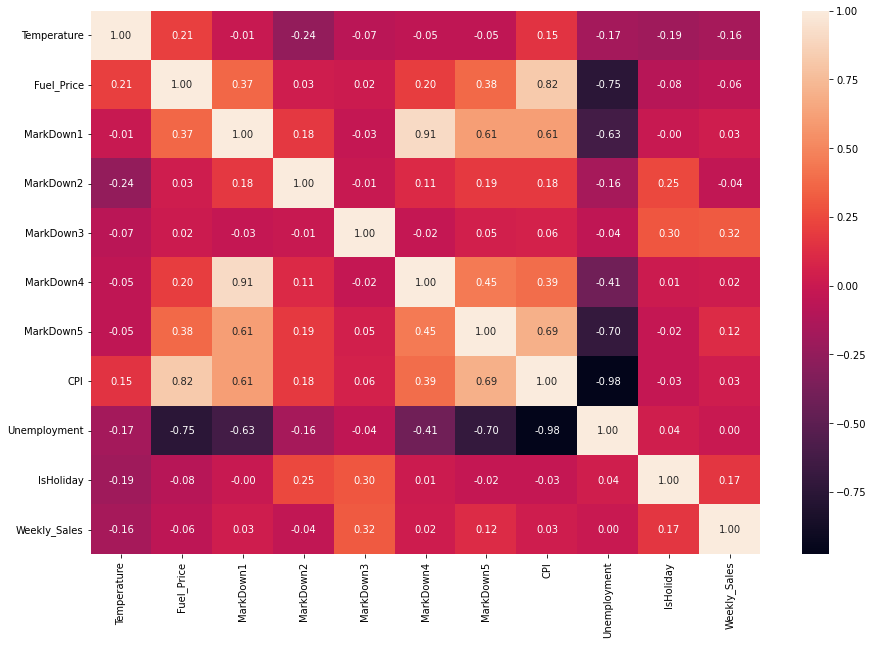

```python
corr = cleaned_features.corr()
plt.figure(figsize=(15, 10))
sns.heatmap(corr, annot=True, fmt=".2f")
plt.show()
```

### More useful metrics for the department chain

In this section, I generate more useful metrics for the department chain. This includes best and worst preforming weeks and stores.

Below are the best and worst preforming weeks by sales

```python
cleaned_features = cleaned_features.sort_values('Weekly_Sales', ascending=False)
cleaned_features.head()
```

|  | Date | Temperature | Fuel_Price | MarkDown1 | MarkDown2 | MarkDown3 | MarkDown4 | MarkDown5 | CPI | Unemployment | IsHoliday | Weekly_Sales |
| --- | --- | --- | --- | --- | --- | --- | --- | --- | --- | --- | --- | --- |
| 46 | 2010-12-24 | 40.360531 | 3.022780 | 0.000000 | 0.000000 | 0.000000 | 0.000000 | 0.000000 | 168.137932 | 8.430285 | False | 80931415.60 |
| 98 | 2011-12-23 | 39.141900 | 3.293627 | 1141.541576 | 57.230030 | 1132.590122 | 90.080489 | 3329.703750 | 173.640008 | 7.766777 | False | 76998241.31 |
| 94 | 2011-11-25 | 49.118040 | 3.435080 | 577.629053 | 174.804886 | 56865.161112 | 58.065915 | 1903.981198 | 173.193448 | 7.761737 | True | 66593605.26 |
| 42 | 2010-11-26 | 47.335946 | 2.919272 | 0.000000 | 0.000000 | 0.000000 | 0.000000 | 0.000000 | 168.206243 | 8.427541 | True | 65821003.24 |
| 45 | 2010-12-17 | 39.562896 | 3.008460 | 0.000000 | 0.000000 | 0.000000 | 0.000000 | 0.000000 | 168.060634 | 8.432456 | False | 61820799.85 |

```python
cleaned_features.tail()
```

|  | Date | Temperature | Fuel_Price | MarkDown1 | MarkDown2 | MarkDown3 | MarkDown4 | MarkDown5 | CPI | Unemployment | IsHoliday | Weekly_Sales |
| --- | --- | --- | --- | --- | --- | --- | --- | --- | --- | --- | --- | --- |
| 49 | 2011-01-14 | 29.995953 | 3.106286 | 0.000000 | 0.000000 | 0.000000 | 0.00000 | 0.000000 | 168.188194 | 8.237757 | False | 40673678.04 |
| 50 | 2011-01-21 | 36.699359 | 3.128344 | 0.000000 | 0.000000 | 0.000000 | 0.00000 | 0.000000 | 168.518097 | 8.226504 | False | 40654648.03 |
| 47 | 2010-12-31 | 36.088264 | 3.051423 | 0.000000 | 0.000000 | 0.000000 | 0.00000 | 0.000000 | 168.073994 | 8.436068 | True | 40432519.00 |
| 103 | 2012-01-27 | 42.088520 | 3.411547 | 1496.648699 | 1751.409434 | 72.227575 | 100.47539 | 2685.466765 | 174.078236 | 7.478244 | False | 39834974.67 |
| 51 | 2011-01-28 | 33.258393 | 3.137512 | 0.000000 | 0.000000 | 0.000000 | 0.00000 | 0.000000 | 168.705433 | 8.242368 | False | 39599852.99 |

Best and worst preforming stores

```python
top_stores = features.groupby(by="Store", as_index=False)["Weekly_Sales"].sum()
top_stores = top_stores.sort_values("Weekly_Sales", ascending=False)
top_stores.head()
```

|  | Store | Weekly_Sales |
| --- | --- | --- |
| 19 | 20 | 3.013978e+08 |
| 3 | 4 | 2.995440e+08 |
| 13 | 14 | 2.889999e+08 |
| 12 | 13 | 2.865177e+08 |
| 1 | 2 | 2.753824e+08 |

```python
top_stores.tail()
```

|  | Store | Weekly_Sales |
| --- | --- | --- |
| 37 | 38 | 55159626.42 |
| 35 | 36 | 53412214.97 |
| 4 | 5 | 45475688.90 |
| 43 | 44 | 43293087.84 |
| 32 | 33 | 37160221.96 |

### Predicting Weekly Sales

I will be using the [Neural Prophet](https://github.com/ourownstory/neural_prophet) model to make predictions in this notebook. Neural Prophet is inspired by Facebook Prophet and is a Neural Network based Time-Series model. Predicting weekly sales is a Time-Series problem becasue we are trying to predict the future given the past data. We cannot use regular machine learning methods such as Linear Regression to predict weekly sales. This is because in testing or application, we do not have access to future data. That means we can't train the model using future data! Then, how do we predict values for time series problems?

Most solutions to time series problems use ARIMA models, which runs under the assumption of a linear relationship between inputs. However, neural network based solutons like Facebook's Neural Prophet do not need to work under this assumtion. Another big advantage of Nerual Network based Time-Series model is that it doesn't require as much data as ARIMA models. Because we are using a Retail Dataset with a very limited amount of data, I opted to use a neural network based time series model, which should work well on this dataset.

Learn more about Time-Series Models: https://en.wikipedia.org/wiki/Time_series Learn more about Neural Network based Time-Series models: https://otexts.com/fpp2/nnetar.html Learn more about ARIMA models: https://otexts.com/fpp2/arima.html

In this section we use MatPlotLib to generate plots. The general documentation can be explored here: https://matplotlib.org/3.3.3/api/_as_gen/matplotlib.pyplot.plot.html

I start by preparing the data into the proper format for the model.

```python
#get data in proper format for neural prophet
cleaned_features = cleaned_features.sort_values("Date")
data = cleaned_features[["Date", "Weekly_Sales"]]
data.columns = ["ds", "y"]
data.head()
```

|  | ds | y |
| --- | --- | --- |
| 0 | 2010-02-05 | 49750740.50 |
| 1 | 2010-02-12 | 48336677.63 |
| 2 | 2010-02-19 | 48276993.78 |
| 3 | 2010-02-26 | 43968571.13 |
| 4 | 2010-03-05 | 46871470.30 |

Training and Results

After training the model, I tested it with 29 weeks of test data. The model seems to preform well with an average error of 5.35%. It could be used to get a rough estimate on how well the department chain would perform over the following month or year. The chain could use this model to optimally manage their finances.

```python
#split data for train and test
data_size = len(data)
train_size = int(data_size * 0.8)
train = data.head(train_size)
test = data.tail(data_size - train_size)

#train neural prophet model
m = NeuralProphet()
m.fit(train, freq="W")

#run predictions on test data and calculate errors
future = m.make_future_dataframe(train, periods=29)
future["ds"] = future["ds"] + timedelta(days=5)
predictions = m.predict(future)
predictions = predictions.drop("y", 1)
predictions = pd.merge(predictions, test, on=["ds"], how="left")
print("Average error:", round((abs((predictions["y"] - predictions["yhat1"])).sum())/29, 2))
print("Average % error:", round((((abs((predictions["y"] - predictions["yhat1"]))/predictions["y"]).sum())/29) * 100, 2))
```

[output not shown]

```
INFO: nprophet - _lr_range_test: learning rate range test found optimal lr: 2.85E-01
```

```
Average error: 2469800.3
Average % error: 5.35
```

Predicting Weekly Sales Over The Next 2 Years

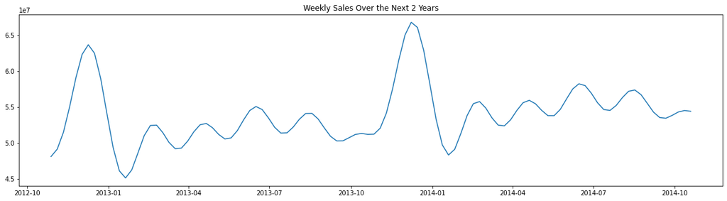

```python
next_year_data = m.make_future_dataframe(data, periods=104)
predictions = m.predict(next_year_data)
predictions.columns = ["Date", "y", "Weekly_Sales", "residual1", "trend", "season_yearly"]

plt.figure(figsize=(20,5))
plt.plot(predictions.Date, predictions.Weekly_Sales)
plt.title("Weekly Sales Over the Next 2 Years")
plt.show()
```

### Extending this approach to CPI, Fuel Price, Temperature, and Unemployment

In this section we will extend the above approach for predicting weekly sales to CPI, fuel price, temperature, and unemployment.

Preparing the data for the model

```python
cleaned_features = features.dropna(subset=["CPI", "Unemployment"])
cleaned_features = cleaned_features.groupby(by="Date", as_index=False)["CPI", "Unemployment", "Temperature"].mean()
cpi_data = cleaned_features[["Date", "CPI"]]
unemp_data = cleaned_features[["Date", "Unemployment"]]
temp_data = cleaned_features[["Date", "Temperature"]]
cleaned_features = features.dropna(subset=["Fuel_Price"])
cleaned_features = cleaned_features.groupby(by="Date", as_index=False)["Fuel_Price"].mean()
fuel_data = cleaned_features[["Date", "Fuel_Price"]]
```

### Training and Results

The model is able to predict CPI and Unemployment really well with an average error only 0.17% and 1.32% respectivly. The prediction for temperature is acceptable. It is enough to give a rough idea of the weather outside. However, the predictions for fuel price are not very accurate. Since CPI and Fuel Price have a strong coorelation, perhaps in the future I could use the CPI prediction to help predict the Fuel Price more accuratly.

```python
data = [cpi_data, fuel_data, unemp_data, temp_data]
names = ["CPI", "Fuel_Price", "Unemployment", "Temperature"]
models = []
for i in range(len(data)):
  #getting proper format for column names
  data[i].columns = ["ds", "y"]

  #split data into train and test
  data_size = len(data[i])
  train_size = int(data_size * 0.8)
  train = data[i].head(train_size)
  test = data[i].tail(data_size - train_size)

  #fit model
  m = NeuralProphet()
  m.fit(train, freq="W", epochs=237)
  models.append(m)

  #test predictions
  future = m.make_future_dataframe(train, periods=29)
  future["ds"] = future["ds"] + timedelta(days=5)
  predictions = m.predict(future)
  predictions = predictions.drop("y", 1)
  predictions = pd.merge(predictions, test, on=["ds"], how="left")
  print("Average" + names[i] +  " error:", round((abs((predictions["y"] - predictions["yhat1"])).sum())/29, 2))
  print("Average " + names[i] +  " % error:", round((((abs((predictions["y"] - predictions["yhat1"]))/predictions["y"]).sum())/29) * 100, 2))
  print("\n")
```

[output not shown]

[output not shown]

```
AverageCPI error: 0.3
Average CPI % error: 0.17
```

[output not shown]

```
AverageFuel_Price error: 0.43
Average Fuel_Price % error: 12.16
```

[output not shown]

```
AverageUnemployment error: 0.09
Average Unemployment % error: 1.32
```

```
INFO: nprophet - _lr_range_test: learning rate range test found optimal lr: 3.51E-01
```

```
AverageTemperature error: 2.93
Average Temperature % error: 6.29
```

Predicting CPI, Fuel Price, Unemployment, and Temperature Over the Next 2 Years

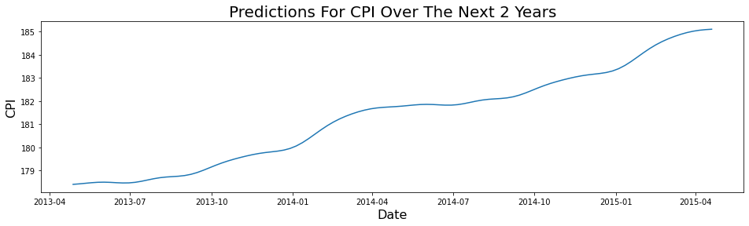

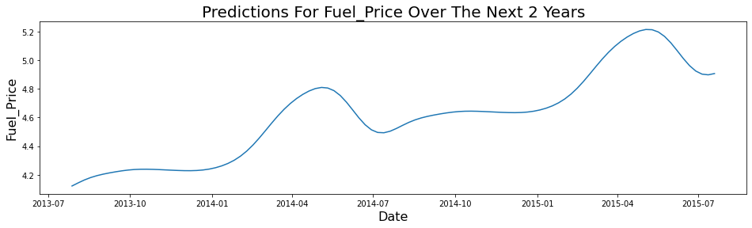

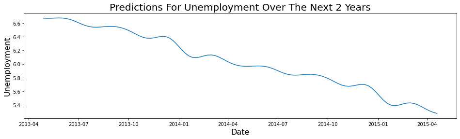

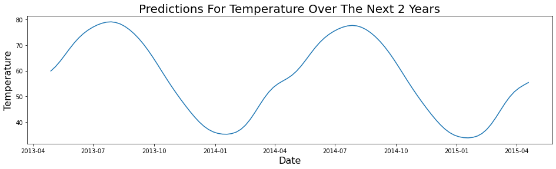

```python
for i in range(len(data)):
  next_year_data = m.make_future_dataframe(data[i], periods=104)
  predictions = models[i].predict(next_year_data)
  predictions.columns = ["Date", "y", names[i], "residual1", "trend", "season_yearly"]


  plt.figure(figsize=(16,4))
  plt.plot(predictions.Date, predictions[names[i]])
  plt.xlabel("Date", fontsize=16)
  plt.ylabel(names[i], fontsize=16)
  plt.title("Predictions For " + names[i] + " Over The Next 2 Years", fontsize=20)
  plt.show()
  print("\n")
```

### Conclusion

While exploring this dataset, I have found many intersting things. The department chain as a whole tends to have a spike in weekly sales around the winter holidays. This is also the time when they have a spike in their markups. The correlation heatmap showed that weekly sales is not correlated with any of the other columns in the dataset. I also found some unexpected correlations such as markdown 5 and unemployment.

I hope you have learned something new from this tutorial. The power of nerual networks such as Facebook's Neural Prophet is astonishing!